# UB1 – Tutorium Mathe A WS19/20

Anton Hanke

Tutorium: 24/10/2019

# Aufgabe 1

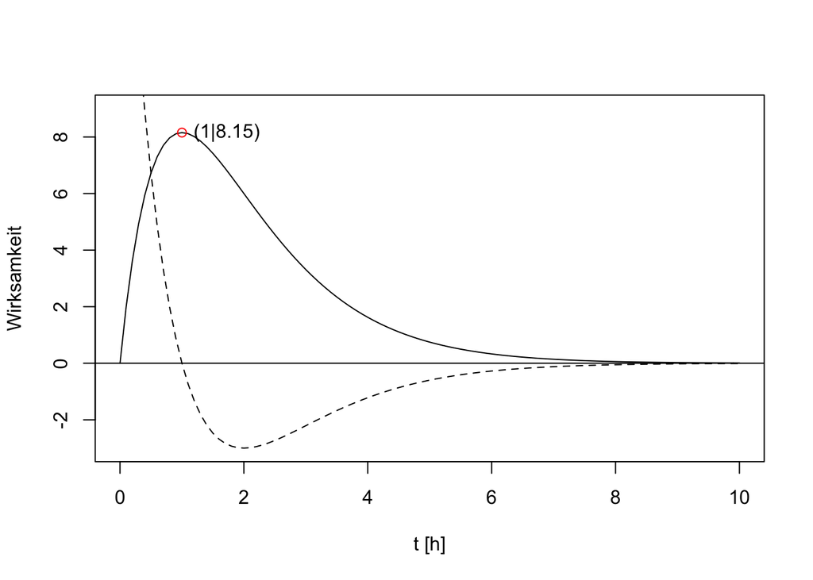

```r
wh <- function(t){3*t*exp(2-t)}
x <- seq(0,10,0.1)
plot(x=x, y=wh(x), ylab= "Wirksamkeit", xlab="t [h]", type = "l", ylim = c(-3, 9))
points(x = 1, y = wh(1), col = "red")
text(x = 1, y = wh(1), labels = paste0("(1|", round(wh(1),2),")"), pos = 4)
dwh <- function(t){(3-3*t)*exp(2-t)}
lines(x = x, y = dwh(x), lty = 2)
abline(h = 0)
```

# Aufgab 2

## Erste Teilaufgabe

Die Lösung von hermann ein wenig anderst hergeleitet, als es die meisten von euch gemacht haben.
$$\begin{aligned}
\overrightarrow{A B} \cdot \overrightarrow{A C} &=1\cdot1+\frac{1}{2}\left(-\frac{1}{2}\right)=\frac{3}{4} \quad\quad |A B|=\left(1^2+\frac{1}{2}^2\right)^{\frac{1}{2}} = \left(1+\frac{1}{4}\right)^{1 / 2} = \frac{\sqrt{5}}{2} \\
&=|AB||AC| \cos \alpha \\
&=\left(\frac{\sqrt{5}}{2}\right)^{2} \cos \alpha=\frac{5}{4} \cos \alpha
\end{aligned}$$

Daraus folgt:
$$\frac{3}{4}=\frac{5}{4} \cos \alpha \quad \Leftrightarrow \quad \cos \alpha=\frac{3}{5}$$

Von euch haben die es einige über den Tangens gelöst mit
$$g_1(x = 2) = 1 \quad g_2(x = 2) = -1$$
Demnach:
$$\alpha = \sum \left|\arctan\left(\frac{1}{2}\right)\right|, \left|\arctan\left(-\frac{1}{2}\right)\right|$$

## Zweite Teilaufgabe

Haben drei Bedingungen:

- Keine Krümmung: $f''(-2)=f''(2) = 0$
- Kein Knick: die Funktion ist bei 2, -2 ableitbar
  - $f(-2) = g_2(-2) = 1$
  - $f(2) = g_1(2) = 1$
- Gleiche Steigung bei -2, 2:
  - $f'(-2) = g_2'(-2) = -1/2$
  - $f'(2) = g_1'(2) = 1/2$

## Dritte Teilaufgabe

Relevante Ableitungen:
$$\begin{array}{l}{f(x)=a x^{4}+b x^{2}+c} \\ {f^{\prime}(x)=4 a x^{3}+2b x} \\ {f^{\prime \prime}(x)=12 a x^{2}+2 b}\end{array}$$

Nach einsetzen von dem jeweiligen $x$ in die Gleichungen erhalten wir folgendes Gleichungssystem:
$$\left\{\begin{array}{lll}{16 a+4b+c} & {=1} & {(1)} \\ {32 a+4 b} & {=\frac{1}{2}} & {(2)} \\ {48 a+2b} & {=0} & (3)\end{array}\right.$$
Somit haben wir 3 Gleichungen die nicht voneinander abhängig sind. (Vektoren sind unabhängig voneinander, $\nexists \lambda \in \mathbb{R}: \lambda v_{1}=v_{2}$)

Durch umstellen erhalten wir die Gleichung:
$$f(x) = -\frac{1}{128}x^4+\frac{3}{16}x^2+\frac{3}{8}$$

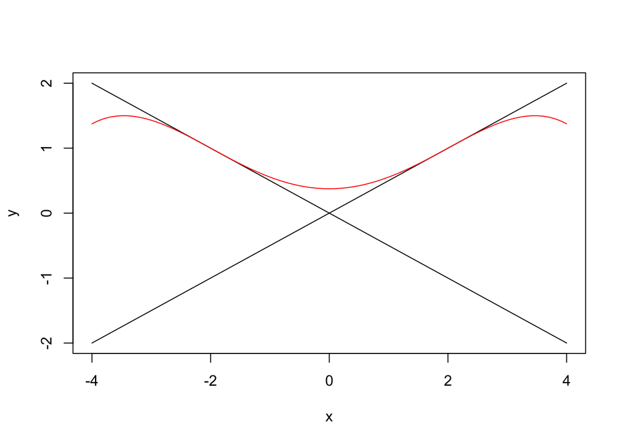

## Vierte Teilaufgabe

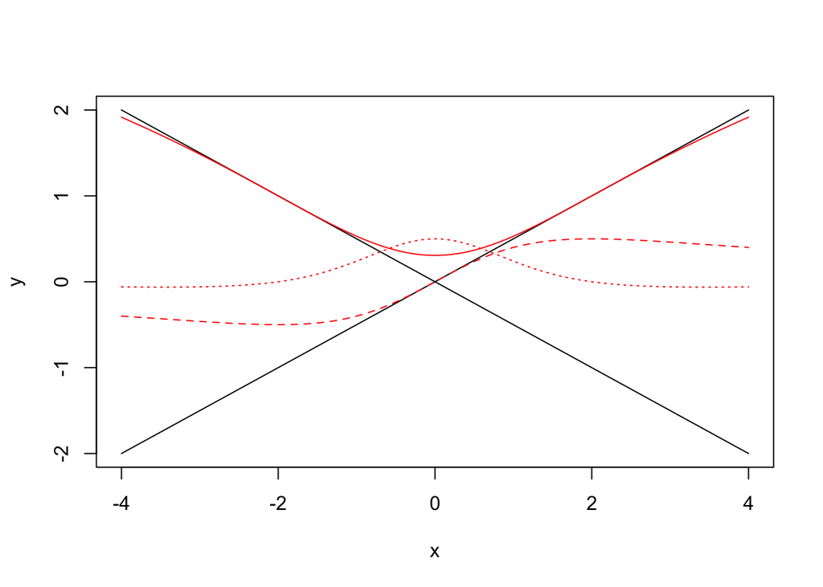

```r
x <- seq(-4,4,0.1)
g1 <- function(x){(1/2)*x}
g2 <- function(x){-(1/2)*x}
f <- function(x){1+log((1/8)*x^2+0.5)}
df <- function(x){(2*x)/(x^2+4)}
ddf <- function(x){(-2*x^2+8)/(x^2+4)^2}
plot(x = x, y = g1(x), type = 'l', ylab = "y")
lines(x = x, y = g2(x))
lines(x = x, y = f(x), col = "red")
lines(x = x, y = df(x), col = "red", lty = 2)
lines(x = x, y = ddf(x), col = "red", lty = 3)
```

1. testen auf symmetry -> setze 2 und -2 ein.
2. ableitungen errechnen
- $h^{\prime}(x)=\frac{1}{4} x\left(\frac{1}{8} x^{2}+\frac{1}{2}\right)^{-1}=\frac{2 x}{x^{2}+4}$
- $h^{\prime \prime}(x)=\frac{2\left(x^{2}+4\right)-2 x(2 x)}{\left(x^{2}+4\right)^{2}}=\frac{-2 x^{2}+8}{\left(x^{2}+4\right)^{2}}$
3. Checken das:
- $|h^{\prime}([2,-2])| = 1/2$ -> selbe steigung
- $h^{\prime\prime}([-2,2]) = 0$ -> Wendepunkte

## Fünfte Teilaufgabe

Suchen eine *symetrische* trigonomische Funktion.
$$\begin{array}{l}{t(x)=a+b \cos (c t)} \\ {t^{\prime}(x)=-c b \cdot \sin (c t)} \\ {t^{\prime\prime}(x)=-c^{2} b \cos (c t)}\end{array}$$
Dabei gilt:

- $a=$ y-achsenabschnitt
- $b=$ amplitude
- $c=$ phasenverschiebung

Bedingungen:

1. $a+b \cos (2 c)=1$
2. $- cb \sin (2 c)=\frac{1}{2}$
3. $-c^{2} b \cos (2 c)=0$

Auflösen von Bedingung 3. nach $c$:
$$\cos(2c) = 0 = \cos(\frac{1}{2}\pi) \Rightarrow c = \frac{1}{4}\pi$$
Einsetzen von $c$ in Bedingung 1:
$$a + b \cos\left(\frac{1}{2}\pi\right) = 1 \Rightarrow a = 1$$
Einsetzen von $c$ in Bedingung 2, umstellen und auflösen:
$$\sin\left(\frac{1}{2}\pi\right) = -\frac{1}{\frac{1}{2}\pi b} = 1 \Rightarrow b = -\frac{2}{\pi}$$
Es ergibt sich nun nach einsetzen folgende Funktion:
$$f(x) = 1 - \frac{2}{\pi} \cdot \cos\left(\frac{\pi}{4}x\right)$$

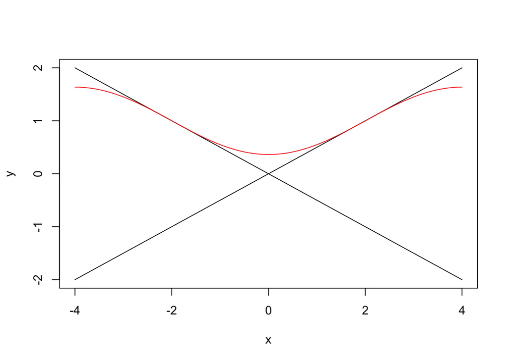

```r
x <- seq(-4,4,0.1)
g1 <- function(x){(1/2)*x}
g2 <- function(x){-(1/2)*x}
f <- function(x){1 - (2/pi) * cos((pi/4)*x)}
plot(x = x, y = g1(x), type = 'l', ylab = "y")
lines(x = x, y = g2(x))
lines(x = x, y = f(x), col = "red")
```